# Pilot experiment with coring and subcoring

## 3.2 TOC measurement

### 3.2.1 Bourgneuf Bay

The difference in LOI measurement between the mixed whole core and the averaged slices ranged between 24.4% and 30.7% for the persistent seagrass meadow with muddy substrate and 16.9% and 60.9% for the sandy substrate. Notably, there was a huge difference in the ‘Sand 3’ replicate (Figure 3.7). When ‘Sand 3’ is excluded, the largest difference is 30.7%. The presence of shells in the slices did not cause any seemingly anomalous patterns to the vertical profile.

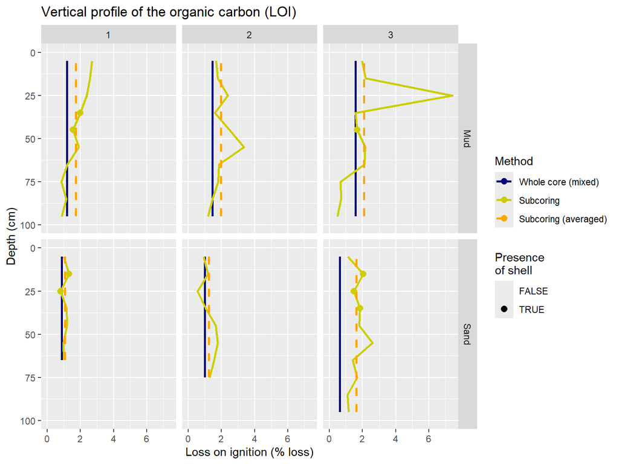

Figure 3.7: Benthic soil/substrate LOI measurement vertical profile at Bourgneuf Bay. The two different methods are represented by different colours and the averaged values of all the slices are represented by a dotted line. Any points with the presence of shells in the sample are highlighted with a solid dot.

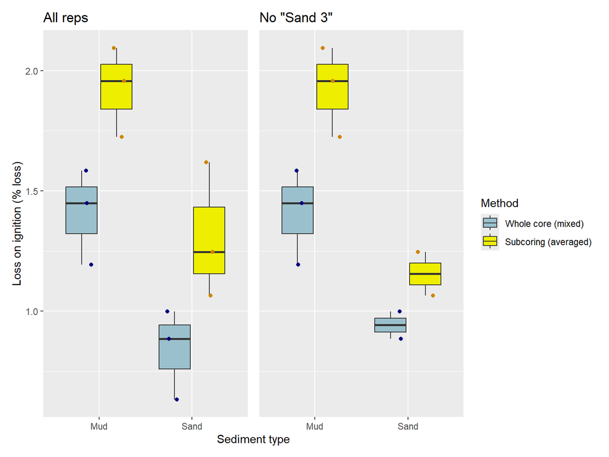

Figure 3.8: Boxplot of the LOI at Bourgneuf Bay using the whole core (mixed) approach and the aggregated subcoring approach.

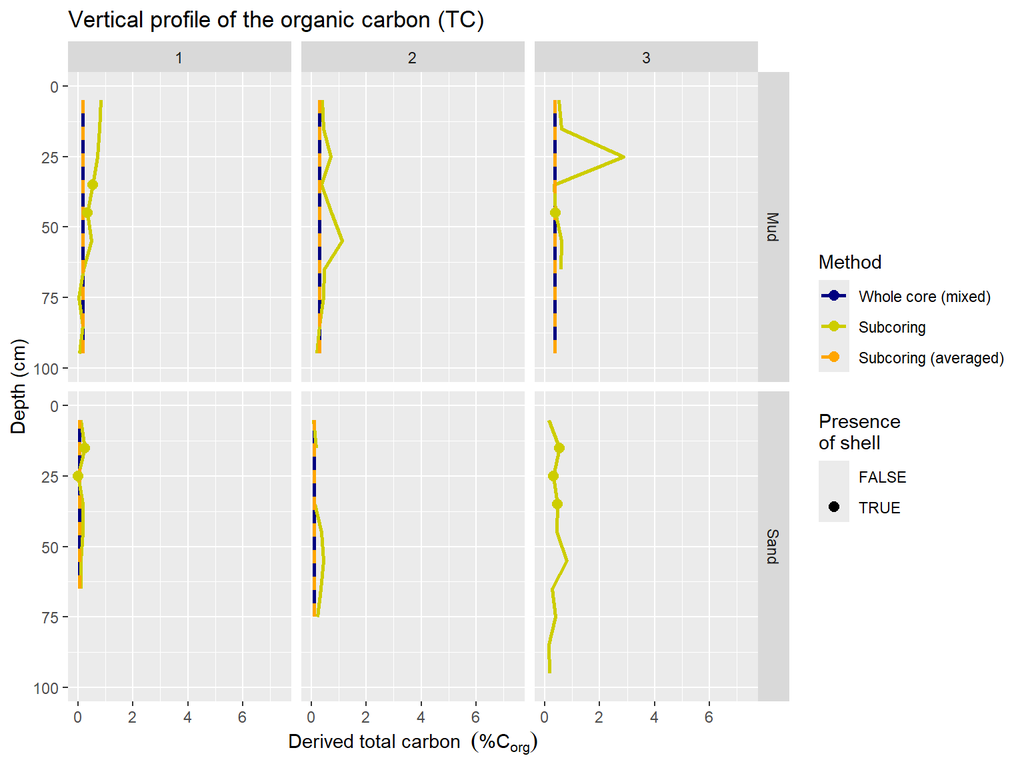

Figure 3.9: Benthic soil/substrate derived TC vertical profile at Bourgneuf Bay. The two different methods are represented by different colours and the averaged values of all the slices are represented by a dotted line. Any points with the presence of shells in the sample are highlighted with a solid dot.

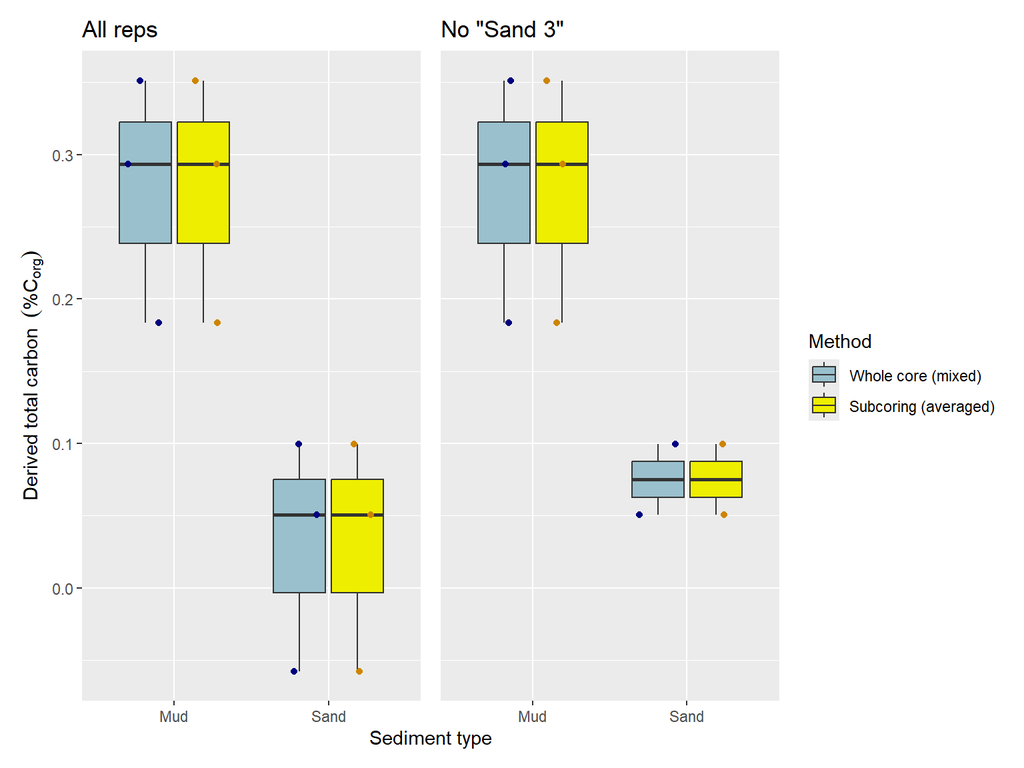

Figure 3.10: Boxplot of the TC at Bourgneuf Bay using the whole core (mixed) approach and the aggregated subcoring approach.

### 3.2.2 Paimpol

Work in progress.

# 4 Future Work

More to come!

# References

Fourqurean, James W, Carlos M Duarte, Hilary Kennedy, Núria Marbà, Marianne Holmer, Miguel Angel Mateo, Eugenia T Apostolaki, et al. 2012. “Seagrass Ecosystems as a Globally Significant Carbon Stock.” *Nature Geoscience* 5 (7): 505–9. https://doi.org/https://doi.org/10.1038/ngeo1477.

Howard, Jennifer, Sarah Hoyt, Kirsten Isensee, Emily Pidgeon, and Maciej Telszewski, eds. 2014. “Coastal Blue Carbon: Methods for Assessing Carbon Stocks and Emissions Factors in Mangroves, Tidal Salt Marshes, and Seagrass Meadows.” Arlington, Virginia, USA: Conservation International; Intergovernmental Oceanographic Commission of UNESCO; International Union for Conservation of Nature. https://www.thebluecarboninitiative.org/manual.

Malla, Avinab. 2025. *SW Maps*. Kathmandu, Nepal: Aviyaan Tech (P) Ltd; Softwel (P) Ltd. https://play.google.com/store/apps/details?id=np.com.softwel.swmaps&hl=en-US&pli=1.

R Core Team. 2025. *R: A Language and Environment for Statistical Computing*. Vienna, Austria: R Foundation for Statistical Computing. https://www.R-project.org/.